# 美国网贷平台Prosper的用户分析

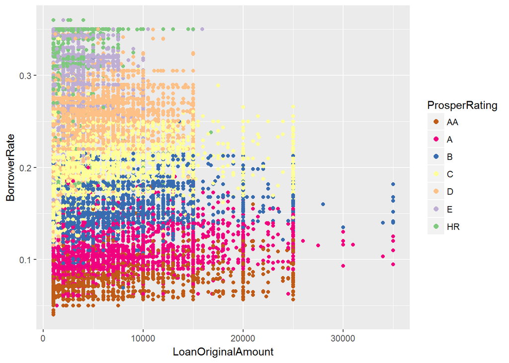

```r
# 2007年7月1日之后:
ggplot(aes(LoanOriginalAmount,BorrowerRate,color = ProsperRating..Alpha.),
       data = subset(loandata,LoanOriginationDate > "2009-07-01"
                     & !is.na(ProsperRating..Alpha.))) +
  geom_point() +
  scale_color_brewer(type = 'qual',
                     guide = guide_legend(title = 'ProsperRating',reverse = TRUE,
                     override.aes = list(alpha = 1, size = 2)))
```

从上面两个图形可以看到，在2009年7月1日前后，数据点有了很大的变化，从借贷资金来看，在时间节点之后， prosper开始借出一些超过25000的资金，并且由于2009年之后，prosper发展迅速，后图拥有更多的点，同时可以看出， ，信用评级越高，prosper贷款利率越低。后图图层的显示的更加分明，这也说明了proeper可能在2009年之后对贷款模型进行了修改，贷款利率与客户信用联系更加紧密了。

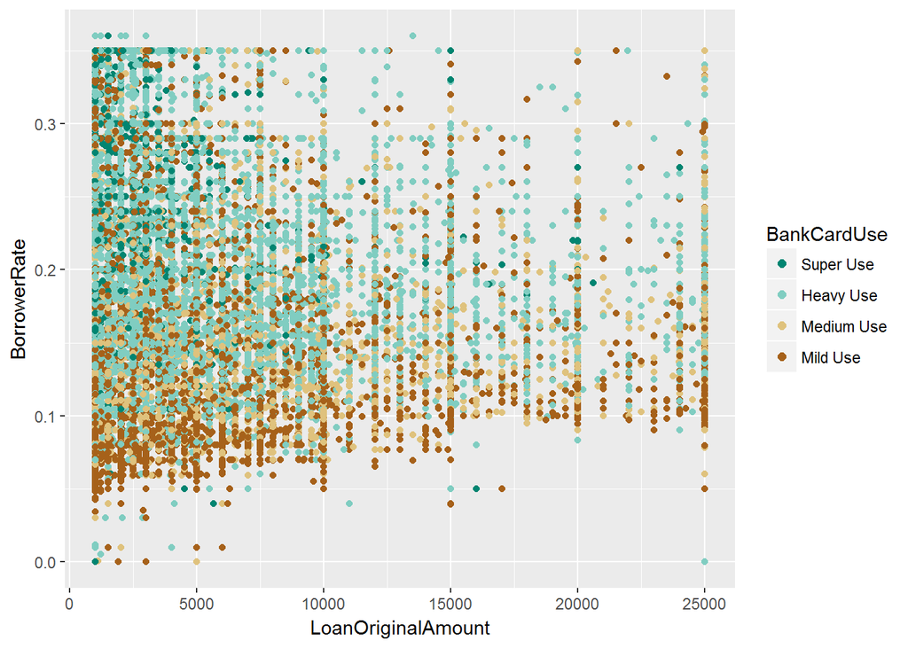

```r
# 贷款利率、贷款总额与信用卡使用的关系:

# 2009年7月1日前:

ggplot(aes(LoanOriginalAmount, BorrowerRate, color = BankCardUse),data = subset(loandata,LoanOriginationDate < "2009-07-01"& CreditGrade != 'NC' &
   !is.na(BankCardUse))) +
  geom_point() +
  scale_color_brewer(type = 'div',
                     guide = guide_legend(title = 'BankCardUse',reverse = TRUE,
                     override.aes = list(alpha = 1, size = 2)))
```

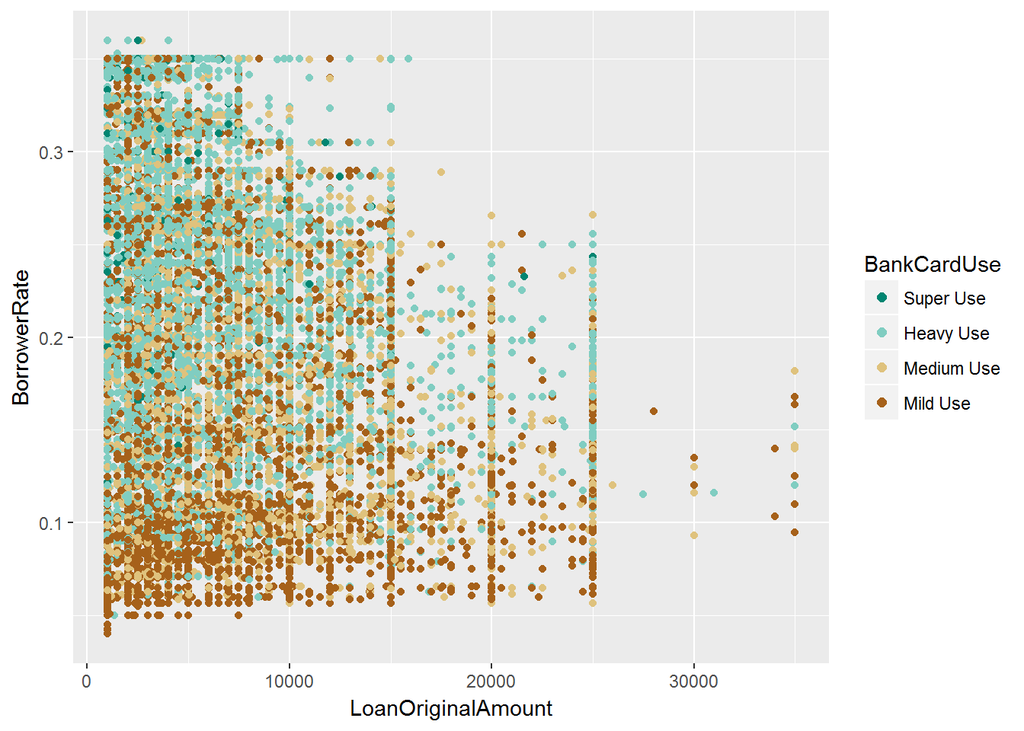

```r
# 2009年7月1日后:

ggplot(aes(LoanOriginalAmount,BorrowerRate,color = BankCardUse),
       data = subset(loandata,LoanOriginationDate > "2009-07-01"
                     & !is.na(BankCardUse))) +
  geom_point() +
  scale_color_brewer(type = 'div',
                     guide = guide_legend(title = 'BankCardUse',reverse = TRUE,
                     override.aes = list(alpha = 1, size = 2)))
```

在信用卡使用程度来看，在时间节点前后似乎并没有什么变化， 但是可以看出信用卡使用率低的用户得到了更低的贷款利率，这似乎验证了我们的观点，信用卡使用率越低，贷款利率也会有所下降。